# Basic-care-and-feeding-of-data-in-R

learn what is **data.frame**

Firstly, loading a data.frame:

```r
library(gapminder)
```

```r
str(gapminder)
```

```
## 'data.frame':    1704 obs. of  6 variables:
##  $ country  : Factor w/ 142 levels "Afghanistan",..: 1 1 1 1 1 1 1 1 1 1 ...
##  $ continent: Factor w/ 5 levels "Africa","Americas",..: 3 3 3 3 3 3 3 3 3 3 ...
##  $ year     : num  1952 1957 1962 1967 1972 ...
##  $ lifeExp  : num  28.8 30.3 32 34 36.1 ...
##  $ pop      : num  8425333 9240934 10267083 11537966 13079460 ...
##  $ gdpPercap: num  779 821 853 836 740 ...
```

```r
head(gapminder)
```

```
##       country continent year lifeExp      pop gdpPercap
## 1 Afghanistan      Asia 1952  28.801  8425333  779.4453
## 2 Afghanistan      Asia 1957  30.332  9240934  820.8530
## 3 Afghanistan      Asia 1962  31.997 10267083  853.1007
## 4 Afghanistan      Asia 1967  34.020 11537966  836.1971
## 5 Afghanistan      Asia 1972  36.088 13079460  739.9811
## 6 Afghanistan      Asia 1977  38.438 14880372  786.1134
```

```r
tail(gapminder)
```

```
##       country continent year lifeExp      pop gdpPercap
## 1699 Zimbabwe    Africa 1982  60.363  7636524  788.8550
## 1700 Zimbabwe    Africa 1987  62.351  9216418  706.1573
## 1701 Zimbabwe    Africa 1992  60.377 10704340  693.4208
## 1702 Zimbabwe    Africa 1997  46.809 11404948  792.4500
## 1703 Zimbabwe    Africa 2002  39.989 11926563  672.0386
## 1704 Zimbabwe    Africa 2007  43.487 12311143  469.7093
```

```r
gapminder[sample(nrow(gapminder), 10), ]
```

```
##             country continent year lifeExp      pop  gdpPercap
## 1246       Portugal    Europe 1997  75.970 10156415 17641.0316
## 307        Colombia  Americas 1982  66.653 27764644  4397.5757
## 366   Cote d'Ivoire    Africa 1977  52.374  7459574  2517.7365
## 36          Algeria    Africa 2007  72.301 33333216  6223.3675
## 1597 United Kingdom    Europe 1952  69.180 50430000  9979.5085
## 89          Bahrain      Asia 1972  63.300   230800 18268.6584
## 1021        Morocco    Africa 1952  42.873  9939217  1688.2036
## 964      Mauritania    Africa 1967  46.289  1230542  1421.1452
## 1294         Rwanda    Africa 1997  36.087  7212583   589.9445
## 387            Cuba  Americas 1962  65.246  7254373  5180.7559
```

```r
names(gapminder)
```

```
## [1] "country"   "continent" "year"      "lifeExp"   "pop"       "gdpPercap"
```

```r
ncol(gapminder)
```

```
## [1] 6
```

```r
length(gapminder)
```

```
## [1] 6
```

```r
head(rownames(gapminder))
```

```
## [1] "1" "2" "3" "4" "5" "6"
```

```r
dim(gapminder)
```

```
## [1] 1704    6
```

```r
nrow(gapminder)
```

```
## [1] 1704
```

```r
rownames(gapminder)
```

[output not shown]

[output cut: 175 more lines]

```r
colnames(gapminder)
```

```
## [1] "country"   "continent" "year"      "lifeExp"   "pop"       "gdpPercap"
```

```r
summary(gapminder)
```

```
##         country        continent        year         lifeExp
##  Afghanistan:  12   Africa  :624   Min.   :1952   Min.   :23.60
##  Albania    :  12   Americas:300   1st Qu.:1966   1st Qu.:48.20
##  Algeria    :  12   Asia    :396   Median :1980   Median :60.71
##  Angola     :  12   Europe  :360   Mean   :1980   Mean   :59.47
##  Argentina  :  12   Oceania : 24   3rd Qu.:1993   3rd Qu.:70.85
##  Australia  :  12                  Max.   :2007   Max.   :82.60
##  (Other)    :1632
##       pop              gdpPercap
##  Min.   :6.001e+04   Min.   :   241.2
##  1st Qu.:2.794e+06   1st Qu.:  1202.1
##  Median :7.024e+06   Median :  3531.8
##  Mean   :2.960e+07   Mean   :  7215.3
##  3rd Qu.:1.959e+07   3rd Qu.:  9325.5
##  Max.   :1.319e+09   Max.   :113523.1
##
```

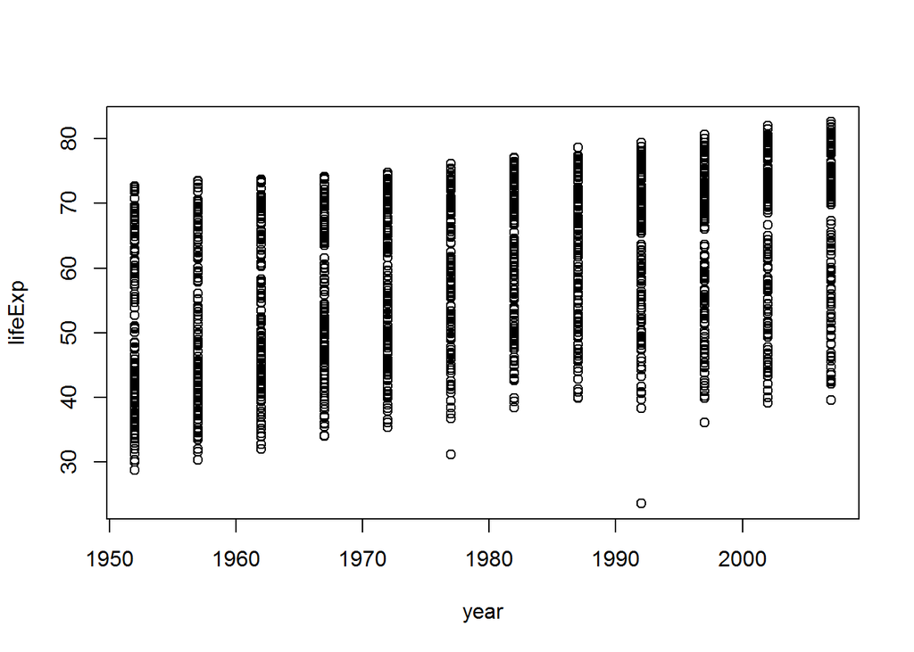

```r
plot(lifeExp ~ year, gapminder)
```

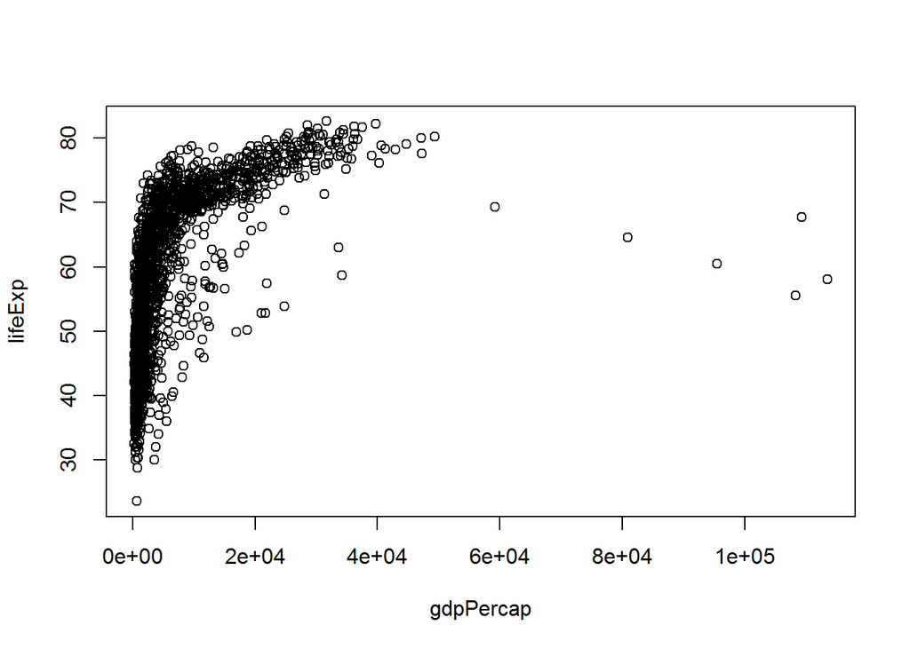

```r
plot(lifeExp ~ gdpPercap, gapminder)
```

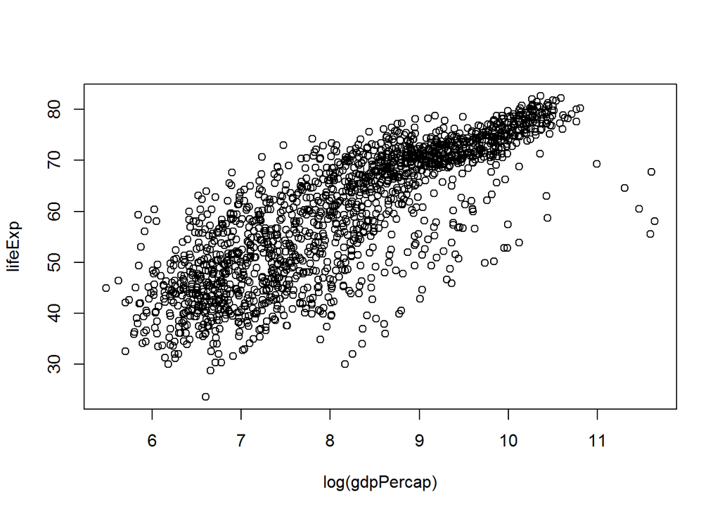

```r
plot(lifeExp ~ log(gdpPercap), gapminder)
```

To specify a single variable from a data.frame, use the dollar sign `$`

```r
head(gapminder$lifeExp)
```

```
## [1] 28.801 30.332 31.997 34.020 36.088 38.438
```

```r
summary(gapminder$lifeExp)
```

```
##    Min. 1st Qu.  Median    Mean 3rd Qu.    Max.
##   23.60   48.20   60.71   59.47   70.85   82.60
```

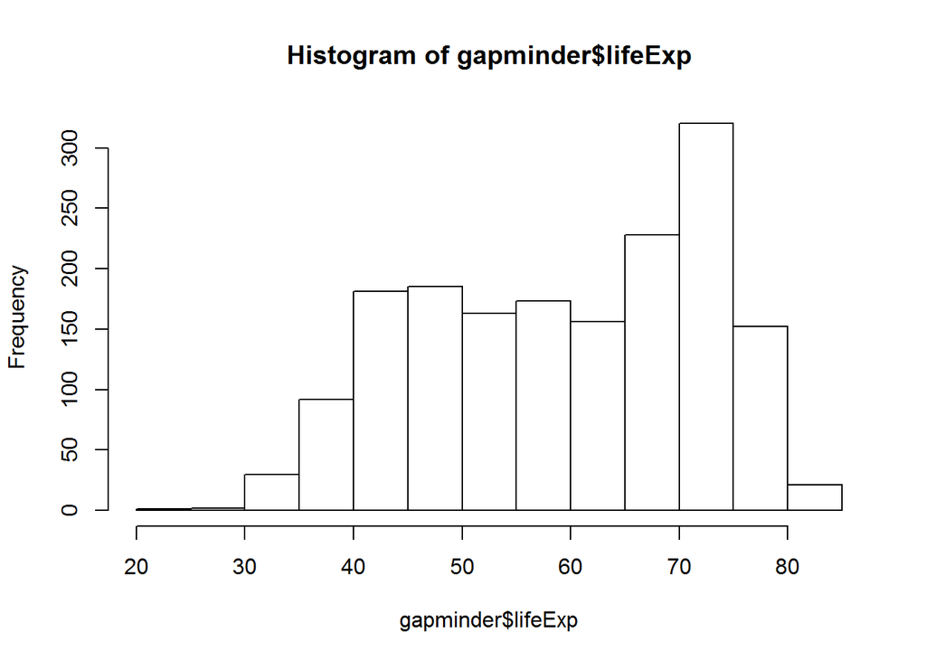

```r
hist(gapminder$lifeExp)
```

```r
summary(gapminder$year)
```

```
##    Min. 1st Qu.  Median    Mean 3rd Qu.    Max.
##    1952    1966    1980    1980    1993    2007
```

```r
table(gapminder$year)
```

```
##
## 1952 1957 1962 1967 1972 1977 1982 1987 1992 1997 2002 2007
##  142  142  142  142  142  142  142  142  142  142  142  142
```

```r
class(gapminder$continent)
```

```
## [1] "factor"
```

```r
summary(gapminder$continent)
```

```
##   Africa Americas     Asia   Europe  Oceania
##      624      300      396      360       24
```

```r
levels(gapminder$continent)
```

```
## [1] "Africa"   "Americas" "Asia"     "Europe"   "Oceania"
```

```r
nlevels(gapminder$continent)
```

```
## [1] 5
```

```r
table(gapminder$continent)
```

```
##
##   Africa Americas     Asia   Europe  Oceania
##      624      300      396      360       24
```

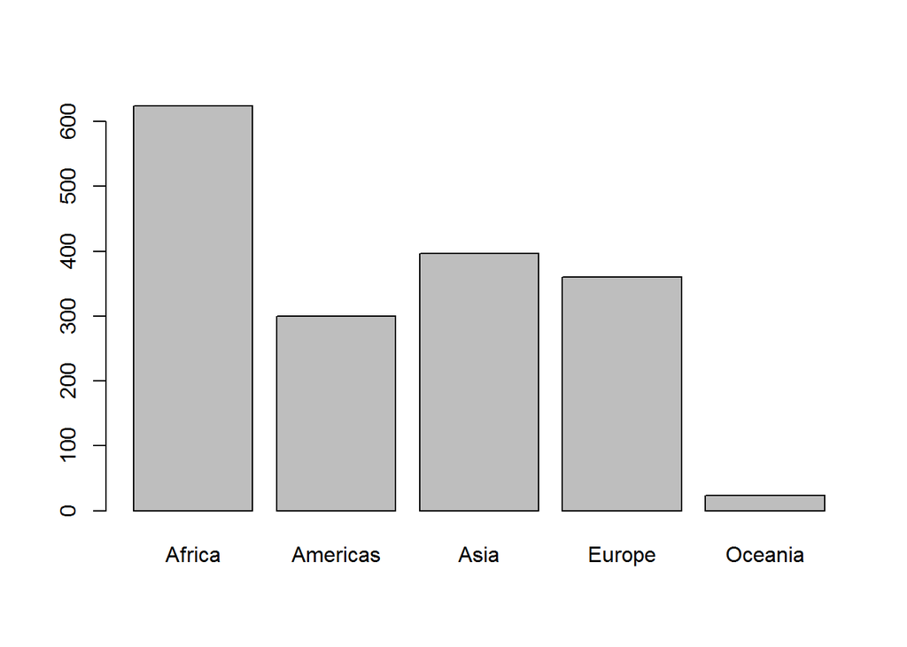

```r
barplot(table(gapminder$continent))
```

`subset()` is a nice way to isolate bits of data.frames (and other things)

```r
subset(gapminder, subset = country == "Uruguay")
```

```
##      country continent year lifeExp     pop gdpPercap
## 1621 Uruguay  Americas 1952  66.071 2252965  5716.767
## 1622 Uruguay  Americas 1957  67.044 2424959  6150.773
## 1623 Uruguay  Americas 1962  68.253 2598466  5603.358
## 1624 Uruguay  Americas 1967  68.468 2748579  5444.620
## 1625 Uruguay  Americas 1972  68.673 2829526  5703.409
## 1626 Uruguay  Americas 1977  69.481 2873520  6504.340
## 1627 Uruguay  Americas 1982  70.805 2953997  6920.223
## 1628 Uruguay  Americas 1987  71.918 3045153  7452.399
## 1629 Uruguay  Americas 1992  72.752 3149262  8137.005
## 1630 Uruguay  Americas 1997  74.223 3262838  9230.241
## 1631 Uruguay  Americas 2002  75.307 3363085  7727.002
## 1632 Uruguay  Americas 2007  76.384 3447496 10611.463
```

```r
#equals to:
gapminder[1621:1632, ]
```

```
##      country continent year lifeExp     pop gdpPercap
## 1621 Uruguay  Americas 1952  66.071 2252965  5716.767
## 1622 Uruguay  Americas 1957  67.044 2424959  6150.773
## 1623 Uruguay  Americas 1962  68.253 2598466  5603.358
## 1624 Uruguay  Americas 1967  68.468 2748579  5444.620
## 1625 Uruguay  Americas 1972  68.673 2829526  5703.409
## 1626 Uruguay  Americas 1977  69.481 2873520  6504.340
## 1627 Uruguay  Americas 1982  70.805 2953997  6920.223
## 1628 Uruguay  Americas 1987  71.918 3045153  7452.399
## 1629 Uruguay  Americas 1992  72.752 3149262  8137.005
## 1630 Uruguay  Americas 1997  74.223 3262838  9230.241
## 1631 Uruguay  Americas 2002  75.307 3363085  7727.002
## 1632 Uruguay  Americas 2007  76.384 3447496 10611.463
```

Yes, these both return the same result. But the second command is horrible for these reasons:

1, It contains *Magic Numbers*. The reason for keeping rows 1621 to 1632 will be non-obvious to someone else and that includes you in a couple of weeks. 2, It is fragile. If the rows of gapminder are reordered or if some observations are eliminated, these rows may no longer correspond to the Uruguay data.

The subset() function can also be used to select certain variables via the select argument.

```r
subset(gapminder, subset = country == "Mexico", select = c(country, year, lifeExp))
```

```
##     country year lifeExp
## 985  Mexico 1952  50.789
## 986  Mexico 1957  55.190
## 987  Mexico 1962  58.299
## 988  Mexico 1967  60.110
## 989  Mexico 1972  62.361
## 990  Mexico 1977  65.032
## 991  Mexico 1982  67.405
## 992  Mexico 1987  69.498
## 993  Mexico 1992  71.455
## 994  Mexico 1997  73.670
## 995  Mexico 2002  74.902
## 996  Mexico 2007  76.195
```

```r
(minYear <- min(gapminder$year))
```

```
## [1] 1952
```

```r
myFit <- lm(lifeExp ~ I(year - minYear), gapminder, subset = country == "Colombia")
summary(myFit)
```

```
##
## Call:
## lm(formula = lifeExp ~ I(year - minYear), data = gapminder, subset = country ==
##     "Colombia")
##
## Residuals:
##     Min      1Q  Median      3Q     Max
## -2.7841 -0.3816  0.1840  0.8413  1.8034
##
## Coefficients:
##                   Estimate Std. Error t value Pr(>|t|)
## (Intercept)       53.42712    0.71223   75.01 4.33e-15 ***
## I(year - minYear)  0.38075    0.02194   17.36 8.54e-09 ***
## ---
## Signif. codes:  0 '***' 0.001 '**' 0.01 '*' 0.05 '.' 0.1 ' ' 1
##
## Residual standard error: 1.312 on 10 degrees of freedom
## Multiple R-squared:  0.9679, Adjusted R-squared:  0.9647
## F-statistic: 301.3 on 1 and 10 DF,  p-value: 8.537e-09
```

Example: How would you compute the correlation of life expectancy and GDP per capita for the country of Colombia? The cor() function sadly does not offer the usual data = and subset = arguments. Here’s a nice way to combine with() and subset() to accomplish without unnecessary object creation and with fairly readable code.

```r
with(subset(gapminder, subset = country == "Colombia"), cor(lifeExp, gdpPercap))
```

```
## [1] 0.9514699
```

Two important practices

give variables short informative names (lifeExp versus “X5”) refer to variables by name, not by column number This will produce code that is self-documenting and more robust.

**Never ever use attach(). It is evil.**